# S3: Pollino Case Study - The Prior Risk Model

For the Pollino case study, this notebook presents the available input data, the major components of the risk model and the simulation workflow. This notebook focuses on those parts that are specific to this case-study and different from the general and more detailed description in the notebook for the Zurich Case Study.

Available input data | Risk model | Simulation workflow

```python
import pandas as pd
import numpy as np
import matplotlib.pyplot as plt
import os
```

## Available input data

This section discusses the available input data. First, for the individual buildings and then the event characteristics.

For each building the available input data consists of:

- Easting in km ('x')
- Northing in km ('y')
- Eurocode8 Soil Class ('SoilClass')
- Construction year ('ConstrPeriod')
- Height class (Low-, Mid- and High-rise) ('HeightClass')
- Municipality (subregion) identifier ('PRO_COM')

Notebooks S2_a and S2_b describe the pre-processing steps that were applied to obtain this input data.

```python
path_Data = os.path.join(os.getcwd(), 'Italy', 'Polino', 'Data') + os.sep
dfBuil = pd.read_csv(path_Data + 'BuildingsInfo.csv')
dfInput = dfBuil[['x','y','SoilClassEC','ConstrPeriod','HeightClass','PRO_COM']].copy()
# Geo-coordinates in km
dfInput['x'] /= 1000
dfInput['y'] /= 1000
dfInput
```

|  | x | y | SoilClassEC | ConstrPeriod | HeightClass | PRO_COM |
| --- | --- | --- | --- | --- | --- | --- |
| 0 | 4816.123728 | 1899.583044 | A | 1946-1961 | LR | 76092 |
| 1 | 4844.877666 | 1896.740388 | A | 1962-1971 | LR | 76097 |
| 2 | 4812.282065 | 1906.021211 | B | <1919 | LR | 76068 |
| 3 | 4821.062411 | 1893.725570 | A | 1972-1981 | LR | 78149 |
| 4 | 4821.606333 | 1903.181412 | A | 1946-1961 | MR | 76042 |
| ... | ... | ... | ... | ... | ... | ... |
| 20523 | 4816.325000 | 1900.275000 | B | 1919-1945 | LR | 76092 |
| 20524 | 4816.235000 | 1900.695000 | B | 1962-1971 | LR | 76092 |
| 20525 | 4816.455000 | 1900.405000 | B | >1991 | LR | 76092 |
| 20526 | 4817.185000 | 1901.285000 | B | 1946-1961 | LR | 76092 |
| 20527 | 4818.215000 | 1899.155000 | A | >1991 | LR | 76092 |

20528 rows × 6 columns

To ease the numerical handling within the risk model we define the soil class, construction period and the height class as categorical variables. Construction periods '1982-1991' and '>1991' are merged to '>1981'.

```python
dfInput['ConstrPeriod'].replace({'>1991': '>1981'}, inplace=True)
dfInput['ConstrPeriod'].replace({'1982-1991': '>1981'}, inplace=True)

cols = ['SoilClassEC', 'ConstrPeriod', 'HeightClass']

cats = [
        ['A', 'B', 'C', 'D', 'E'],
        ['<1919', '1919-1945', '1946-1961', '1962-1971', '1972-1981', '>1981'],
        ['LR', 'MR', 'HR']
        ]

for cat, col in zip(cats, cols):
    cat_var = pd.Categorical(dfInput[col], ordered=True,
                   categories = cat)
    dfInput[col] = cat_var
```

The event characteristics for this example consist of the earthquake magnitude ('M'), easting and northing coordinates of the epicenter in km ('x','y') and the type-of-faulting ('Faulting').

|  | M | lat | lon | FaultingStyle | x | y |
| --- | --- | --- | --- | --- | --- | --- |
| 0 | 5.6 | 39.979 | 16.026 | Normal faulting | 4837.855425 | 1896.648032 |

```python
from CodePaper.rmgp.modules import EventChar
df_EC = df_EC.squeeze()
EC = EventChar(Magnitude=df_EC.M, xEpi = df_EC.x, yEpi = df_EC.y,
               style_of_faulting='N')
```

## Risk model

Ground motion module | Damage module | Typological attribution module

In contrast to the notebook S1 (Zurich Case Study), this notebook presents the prior risk model directly in its object-oriented implementation, used in the risk-model informed gaussian process (RMGP). The code of RMGP is publicly available.

### Ground motion module

This module builds upon an empirical ground-motion model (GMM) and an empirical spatial correlation model to simulate random fields of a ground-motion intensity measure (IM) conditional on a scenario earthquake with characteristics $\mathbf{e}$. The GMM provides the mean function and the standard deviation of the between-event and within-event residual. The spatial correlation model provides the lengthscale used for the covariance function of the within-event residual. Here we use the GMM of Bindi et al. (2011) [1] and the spatial correlation model of Esposito and Iervolino (2011) [2].

The object SpatialGMM combines a ground-motion model and a spatial correlation model. This is the first module of the RMGP.

References

[1] Bindi, D., Pacor, F., Luzi, L., Puglia, R., Massa, M., Ameri, G., Paolucci, R., (2011): Ground motion prediction equations derived from the Italian strong motion database; Bulletin of Earthquake Engineering, 9:1899-1920; 10.1007/s10518-011-9313-z

[2] Esposito, S. and Iervolino, I. (2011): PGA and PGV Spatial Correlation Models Based on European Multievent Datasets; Bulletin of the Seismological Society of America, 101(5):2532–2541; 10.1785/0120110117

```python
# Load the GMM
from CodePaper.rmgp.gmm_lib.gmms import GMM_BindiEtAl2011
from CodePaper.rmgp.modules import SpatialGMM

GMM = GMM_BindiEtAl2011(column_names = ['x','y','SoilClassEC'])

T = 0.0 # PGA
corr_length = 11.5 # Estimated from Italian data by Esposito and Iervolino (2011)

SpGMM = SpatialGMM(GMM, corr_length, T)
```

The joint prior distribution of function $f=log(im)$ evaluated at the building sites $\mathbf{X}=( \mathbf{x}_i | i \in {1,...,n})$ follows a multivariate normal distribution $p(\mathbf{f}|\mathbf{X}) = \mathcal{N}(\mathbf{m},\mathbf{K})$. Using the SpatialGMM object, the code below shows how to evaluate the mean vector and covariance matrix for the first five buildings.

```python
m = SpGMM.mean_func(dfInput.iloc[:5], EC)
K = SpGMM.cov_func(dfInput.iloc[:5])
```

### Damage module

First, load the vulnerability functions in a dataframe ('df_frag') and arrange the threshold parameters in matrix $\boldsymbol{\eta}$ ('etas') and the dispersion parameters in vector $\boldsymbol{\beta}$ ('betas'). The herein employed vulnerability functions have been published in [1] and [2], and are also part of the recently published national Italian seismic risk assessment [3].

The vulnerability function parameters are specified for 12 different classes $b\in\mathcal{B}=\{1,2,...,12\}$, where the first six pertain to three classes of unreinforced masonry structures with decreasing suspectibility towards earthquake-induced damage ('A', 'B', 'C1') that are further separated into low-rise (less than 3 stories) and mid-/high-rise buildings (at least 3 stories). The last six pertain to two classes of RC buildings built before ('C1') and after ('D') seismic classification of the region of interest, which are further separated into three height classes low-rise (LR: less than 3 stories) mid-rise (MR: 3 and 4 stories) and high-rise (HR: more than 4 stories). Notebook S2 provides further information on these classes.

The vulnerability functions employ 5+1 damage states (EMS-98), whereas in the case-study we consider 3+1 damage states $y\in\mathcal{Y}=\{0,1,2,3\}$. Specifically, damage states 2 and 3 used by the vulnerability functions are lumped to $y=2$. The damage states 4 and 5 then become damage state $y=3$.

The object DamageEstimationModule collects the vulnerability function parameters $\boldsymbol{\eta}$ and $\boldsymbol{\beta}$. It transforms these parameters into a GPflow likelihood object that is used for inference using inspection data. This is the second module of the RMGP.

[1] Rosti A., Rota M. and Penna A. (2021): Empirical fragility curves for Italian URM buildings; Bulletin of Earthquake Engineering 19:3057–3076; 10.1007/s10518-020-00845-9

[2] Rosti A., Del Gaudio C., Rota M., Ricci P., Di Ludovico M., Penna A. and Verderame G.M. (2021): and Penna A. (2021): Empirical fragility curves for Italian residential RC buildings; Bulletin of Earthquake Engineering 19:3165–3183; 10.1007/s10518-020-00971-4

[3] Dolce M., Prota A., Borzi B., Da Porto F., Lagomarsino S. et al. (2021): Seismic risk assessment of residential buildings in Italy; Bulletin of Earthquake Engineering 19:2999-3032; 10.1007/s10518-020-01009-5

```python
path_Frag = os.path.join(os.getcwd(), 'Italy') + os.sep
df_frag = pd.read_csv(path_Frag + 'Fragility_Rosti.csv', delimiter=';')
betas = df_frag.beta.values.reshape(-1,1)
etas = np.zeros((len(df_frag),5))
for ds in np.arange(5):
    etas[:,ds] = np.log(df_frag['eta'+str(ds+1)].values)

# lump damage states to the damage states considered in the present study.
etas[:, 2] = etas[:, 3]
etas = etas[:, :3]

from CodePaper.rmgp.modules import DamageEstimationModule
DEM = DamageEstimationModule(etas, betas)
```

The following Figure illustrates the vulnerability functions of three classes.

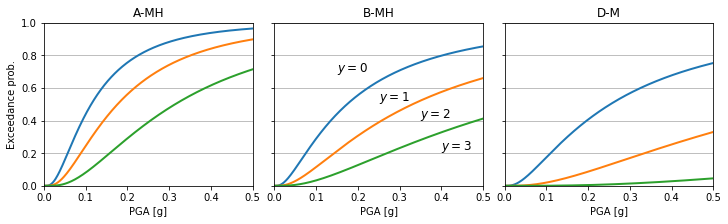

### Typological attribution module

The present model categorizes residential buildings in the case-study region into four unkown typological attribute combinations $a\in\mathcal{A}=\{1,2,3,4\}$:

- $a=1$ : Unreinforced masonry of class A
- $a=2$ : Unreinforced masonry of class B
- $a=3$ : Unreinforced masonry of class C1
- $a=4$ : Reinforced concrete

These attribute combinations are modelled via four latent functions $\mathbf{g}$ that follow independent gaussian processes with an identical covariance function but different mean functions. Conditional on realizations from these four latent functions, the class membership probabilities $p(A=a|\mathbf{g},\mathbf{X})$ are calculated via the softmax function. Conditional on the sampled attribute combinations and the input information, we then map to the vulnerability types from above using a deterministic function. The following paragraphs walk you through the different parts of the model starting with the mean function.

#### Mean functions

The mean functions of the latent functions $\mathbf{g}$ are based on an expert-based attribution model that comes in the form of a conditional probability table. Specifically, the herein assumed model provides class membership probabilities conditional on six construction periods and separates between low-rise buildings and mid-/high-rise buildings. The two tables are shown below.

```
Conditional Probability Table for low-rise buildings
```

|  | ConPeriod | p_A | p_B | p_C1 | p_RC |
| --- | --- | --- | --- | --- | --- |
| 0 | cy $\leq$ 1919 | 0.8600 | 0.0000 | 0.1400 | 0.00 |
| 1 | 1919 $<$ cy $\leq$ 1945 | 0.4365 | 0.4268 | 0.1067 | 0.03 |
| 2 | 1945 $<$ cy $\leq$ 1961 | 0.0819 | 0.5369 | 0.2912 | 0.09 |
| 3 | 1961 $<$ cy $\leq$ 1971 | 0.0385 | 0.0308 | 0.7007 | 0.23 |
| 4 | 1971 $<$ cy $\leq$ 1981 | 0.0000 | 0.0000 | 0.5500 | 0.45 |
| 5 | cy $>$ 1981 | 0.0000 | 0.0000 | 0.3000 | 0.70 |

```
Conditional Probability Table for mid- and high-rise buildings
```

|  | ConPeriod | p_A | p_B | p_C1 | p_RC |
| --- | --- | --- | --- | --- | --- |
| 0 | cy $\leq$ 1919 | 0.9700 | 0.0000 | 0.0300 | 0.00 |
| 1 | 1919 $<$ cy $\leq$ 1945 | 0.2134 | 0.7566 | 0.0000 | 0.03 |
| 2 | 1945 $<$ cy $\leq$ 1961 | 0.0000 | 0.6825 | 0.2275 | 0.09 |
| 3 | 1961 $<$ cy $\leq$ 1971 | 0.0000 | 0.1386 | 0.6314 | 0.23 |
| 4 | 1971 $<$ cy $\leq$ 1981 | 0.0000 | 0.0000 | 0.5500 | 0.45 |
| 5 | cy $>$ 1981 | 0.0000 | 0.0000 | 0.3000 | 0.70 |

Because we assume to know the construction period and not the exact construction year as in the Zurich case study (notebook S1), these conditional probability tables are not smoothed. The mean functions $\mathbf{u}(\mathbf{x})$ of the four gaussian processes $\mathbf{g}$ are the logarithmic probabilities stated in the aforementioned tables.

First combine both tables in a three-dimensional array and then define a function that attributes the mean values to each building based on its construction period and height class.

```python
# Add a small value to zero entries and normalize such that the rows sum up to one
AttMat = df_am_LR.iloc[:, 1:].values
AttMat[AttMat==0] += 0.001
AttMat_LR = AttMat / np.sum(AttMat,axis=1).reshape(-1,1)
AttMat = df_am_MHR.iloc[:, 1:].values
AttMat[AttMat==0] += 0.001
AttMat_MHR = AttMat / np.sum(AttMat,axis=1).reshape(-1,1)

# Combine to a three dimensional array (last dimension indicates the height class)
AttMat = np.concatenate([AttMat_LR[:,:, None], AttMat_MHR[:,:,None], AttMat_MHR[:,:, None] ], axis=-1)

def mean_prior_prob_ta(df_target, AttMat):
    C_A = AttMat.shape[1]
    CP = df_target['ConstrPeriod'].values.codes
    HC = df_target['HeightClass'].values.codes
    Xm = np.zeros((len(df_target), C_A))
    for bc in np.arange(C_A):
        for cp in np.arange(6):
            for hc in np.arange(3):
                Xm[:, bc] += AttMat[cp, bc, hc] * ((CP==cp) & (HC==hc))
    return Xm
```

#### Covariance function

The covariance function of the gaussian process is a combination of four individual functions. The first one ('v_ls') uses the spatial distance with a lengthscale of 5 km to account for long-scale spatial correlations. The second one ('v_ss') is the multiplication of three functions, using spatial distance (but with a shorter length-scale of 0.15 km) and similarites with respect to construction period and height class.

Because the construction period and height class are discrete variables, we specify a linear kernel on these attributes. Specifically, this covariance function considers buildings as correlated if they have the same construction period (for 'v_ss_2') and the same height class (for 'v_ss_3'). The multiplicative structure of the short scale covariance function ('v_ss') models correlations only for geographically close buildings built in the same period and of the same height class.

The object TypologyAttributionModule collects the functions explained above and initializes GPflow compatible kernel (covariance function), mean function and likelihood objects. This is the third, and final, module of the RMGP. The deterministic mapping to vulnerability types is added in the next section.

```python
from CodePaper.rmgp.modules import TypologyAttributionModule
col_names = ['x', 'y', 'ConstrPeriod', 'HeightClass']
TAM = TypologyAttributionModule(AttMat,
                          column_names = col_names,
                          column_dtypes = dfInput[col_names].dtypes,
                          func_assign_vul_class = None,
                          func_prior_mean_prob = mean_prior_prob_ta)
```

The joint prior distribution of latent functions $\mathbf{g}=( \mathbf{g}^{(a)} | a \in \mathcal{A})$ evaluated at the building sites $\mathbf{X}$ follow four independent multivariate normal distributions $p(\mathbf{g^{(a)}}|\mathbf{X}) = \mathcal{N}(\mathbf{u^{(a)}},\mathbf{V})$. Using the TypologyAttributionModule object, the code below shows how to evaluate the mean vector and covariance matrix for the first five buildings.

```python
u = TAM.mean_func(dfInput.iloc[:5])
V = TAM.cov_func(dfInput.iloc[:5])
```

#### Deterministic mapping to vulnerability types

```python
def AssignVulClass(sim_a, df_target):
    height_class = df_target['HeightClass'].values.codes
    con_period = df_target['ConstrPeriod'].values.codes
    sim_b = 2 * sim_a
    # For URM buildings: Separate only low-rise and Mid-/High-rise buildings
    sim_b += (sim_a <= 2) * ((height_class == 0) * 0 + (height_class > 0) * 1)
    # For RC buildings: Separate all height-classes
    sim_b += (sim_a == 3) * ((height_class == 0) * 0 + (height_class == 1) * 1
                             + (height_class == 2) * 2)
    # For RC buildings: Separate pre- and post-code buildings according to the construction period and
    # the seismic classification of the region.
    sim_b += ((sim_a == 3) * (con_period > 2)) * 3
    return sim_b.astype('int')

TAM.func_assign_vul_class = AssignVulClass
```

### RMGP Implemenation

The RMGP object combines the three modules explained above and takes the event characteristics as an additional input. This object is used for prediction and inference using data from seismic stations and building inspections. The inference workflow is explained in the example notebook in the GitLab repository, while the simulation workflow is illustrated below.

```python
from CodePaper.rmgp.model import RMGP
rmgp = RMGP(SpGMM, TAM, DEM, EC)
```

## Simulation workflow

The code below illustrates the simulation workflow for 'numB' buildings and 'numSim' simulations. For a step-by-step explanation the reader is referred to notebook S1.

```python
numB = 100
numSim = 10
dftarget = dfInput.sample(n=numB)
```

```python
sam_n = rmgp.Sample_damage(dftarget, numSim, aggregate=True).T
```